# MultiAssayExperiment Lab

Marcel Ramos and Levi Waldron

July 12, 2018

# R/Bioconductor packages used

Some of these analyses require a *very* recent version of the *TCGAutils* package:

```r
if(!require("BiocManager"))
  install.packages("BiocManager")
BiocManager::install("waldronlab/TCGAutils")
```

Other packages used:

```r
library(MultiAssayExperiment)
library(GenomicRanges)
library(RaggedExperiment)
library(curatedTCGAData)
library(GenomicDataCommons)
library(SummarizedExperiment)
library(SingleCellExperiment)
library(TCGAutils)
library(UpSetR)
library(mirbase.db)
library(AnnotationFilter)
library(EnsDb.Hsapiens.v86)
library(survival)
library(survminer)
library(pheatmap)
```

# Workshop goals and objectives

- identify appropriate data structures for different ’omics data types
- gain familiarity with GRangesList and RaggedExperiment
- create MultiAssayExperiment objects for multi’omics data
- perform subsetting, reshaping, growing, and extraction of a MultiAssayExperiment
- link MultiAssayExperiment data with packages for differential expression, machine learning, and plotting
- use curatedTCGAData to create custom TCGA MultiAssayExperiment objects
- perform survival and correlation analyses on a multi’omics dataset

# Overview of key data classes

This section summarizes three fundamental data classes for the representation of multi-omics experiments.

## `(Ranged)SummarizedExperiment`

[figure not shown]

Figure 1: A matrix-like container where rows represent features of interest and columns represent samples  
The objects contain one or more assays, each represented by a matrix-like object of numeric or other mode.

`SummarizedExperiment` is the most important Bioconductor class for matrix-like experimental data, including from RNA sequencing and microarray experiments. It can store multiple experimental data matrices of identical dimensions, with associated metadata on the rows/genes/transcripts/other measurements (`rowData`), column/sample phenotype or clinical data (`colData`), and the overall experiment (`metadata`). The derivative class `RangedSummarizedExperiment` associates a `GRanges` or `GRangesList` vector with the rows. These classes supersede the use of `ExpressionSet`. Note that many other classes for experimental data are actually derived from `SummarizedExperiment`; for example, the `SingleCellExperiment` class for single-cell RNA sequencing experiments extends `RangedSummarizedExperiment`, which in turn extends `SummarizedExperiment`:

```r
library(SingleCellExperiment)
extends("SingleCellExperiment")
```

```
## [1] "SingleCellExperiment"       "RangedSummarizedExperiment"
## [3] "SummarizedExperiment"       "Vector"
## [5] "Annotated"
```

Thus, although `SingleCellExperiment` provides additional methods over `RangedSummarizedExperiment`, it also inherits all the methods of `SummarizedExperiment` and `RangedSummarizedExperiment`, so everything you learn about `SummarizedExperiment` will be applicable to `SingleCellExperiment`.

## `RaggedExperiment`

`RaggedExperiment` is a flexible data representation for segmented copy number, somatic mutations such as represented in `.vcf` files, and other ragged array schema for genomic location data. Like the `GRangesList` class from `GenomicRanges`, `RaggedExperiment` can be used to represent *differing* genomic ranges on each of a set of samples. In fact, `RaggedExperiment` contains a `GRangesList`:

```r
showClass("RaggedExperiment")
```

```
## Class "RaggedExperiment" [package "RaggedExperiment"]
##
## Slots:
##
## Name:       assays      rowidx      colidx    metadata
## Class: GRangesList     integer     integer        list
##
## Extends: "Annotated"
```

However, `RaggedExperiment` provides a flexible set of *Assay* methods to support transformation of such data to matrix format.

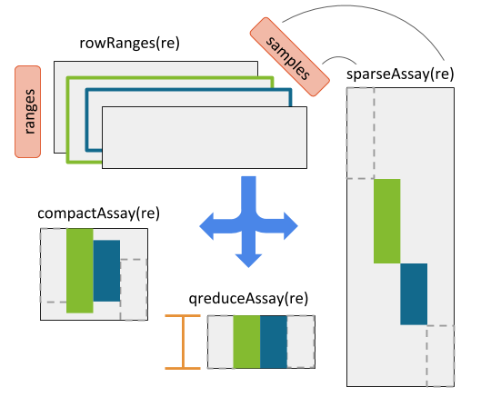

Figure 2: RaggedExperiment object schematic  
Rows and columns represent genomic ranges and samples, respectively. Assay operations can be performed with (from left to right) compactAssay, qreduceAssay, and sparseAssay.

## `MultiAssayExperiment`

`MultiAssayExperiment` is an integrative container for coordinating multi-omics experiment data on a set of biological specimens. As much as possible, its methods adopt the same vocabulary as `SummarizedExperiment`. A `MultiAssayExperiment` can contain any number of assays with different representations. Assays may be *ID-based*, where measurements are indexed identifiers of genes, microRNA, proteins, microbes, etc. Alternatively, assays may be *range-based*, where measurements correspond to genomic ranges that can be represented as `GRanges` objects, such as gene expression or copy number.  
For ID-based assays, there is no requirement that the same IDs be present for different experiments. For range-based assays, there is also no requirement that the same ranges be present for different experiments; furthermore, it is possible for different samples within an experiment to be represented by different ranges. The following data classes have been tested to work as elements of a `MultiAssayExperiment`:

1. `matrix`: the most basic class for ID-based datasets, could be used for example for gene expression summarized per-gene, microRNA, metabolomics, or microbiome data.
2. `SummarizedExperiment` and derived methods: described above, could be used for miRNA, gene expression, proteomics, or any matrix-like data where measurements are represented by IDs.
3. `RangedSummarizedExperiment`: described above, could be used for gene expression, methylation, or other data types referring to genomic positions.
4. `ExpressionSet`: Another rich representation for ID-based datasets, supported only for legacy reasons
5. `RaggedExperiment`: described above, for non-rectangular (ragged) ranged-based datasets such as segmented copy number, where segmentation of copy number alterations occurs and different genomic locations in each sample.
6. `RangedVcfStack`: For VCF archives broken up by chromosome (see `VcfStack` class defined in the `GenomicFiles` package)
7. `DelayedMatrix`: An on-disk representation of matrix-like objects for large datasets. It reduces memory usage and optimizes performance with delayed operations. This class is part of the `DelayedArray` package.

Note that any data class extending these classes, and in fact any data class supporting row and column names and subsetting can be used as an element of a `MultiAssayExperiment`.

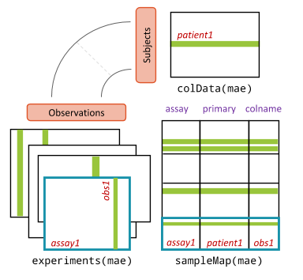

Figure 3: MultiAssayExperiment object schematic  
colData provides data about the patients, cell lines, or other biological units, with one row per unit and one column per variable. The experiments are a list of assay datasets of arbitrary class. The sampleMap relates each column (observation) in ExperimentList to exactly one row (biological unit) in colData; however, one row of colData may map to zero, one, or more columns per assay, allowing for missing and replicate assays. sampleMap allows for per-assay sample naming conventions. Metadata can be used to store information in arbitrary format about the MultiAssayExperiment. Green stripes indicate a mapping of one subject to multiple observations across experiments.

# Working with RaggedExperiment

You can skip this section if you prefer to focus on the functionality of `MultiAssayExperiment`. In most use cases, you would likely convert a `RaggedExperiment` to matrix or `RangedSummarizedExperiment` using one of the `Assay` functions below, and either concatenate this rectangular object to the `MultiAssayExperiment` or use it to replace the `RaggedExperiment`.

## Constructing a `RaggedExperiment` object

We start with a toy example of two `GRanges` objects, providing ranges on two chromosomes in two samples:

```r
sample1 <- GRanges(
    c(A = "chr1:1-10:-", B = "chr1:8-14:+", C = "chr1:15-18:+"),
    score = 3:5, type=c("germline", "somatic", "germline"))
sample2 <- GRanges(
    c(D = "chr1:1-10:-", E = "chr1:11-18:+"),
    score = 11:12, type=c("germline", "somatic"))
```

Include column data `colData` to describe the samples:

```r
colDat <- DataFrame(id=1:2, status = factor(c("control", "case")))
```

The `RaggedExperiment` can be constructed from individual `Granges`:

```r
(ragexp <- RaggedExperiment(
    sample1 = sample1,
    sample2 = sample2,
    colData = colDat))
```

```
## class: RaggedExperiment
## dim: 5 2
## assays(2): score type
## rownames(5): A B C D E
## colnames(2): sample1 sample2
## colData names(2): id status
```

Or from a `GRangesList`:

```r
grl <- GRangesList(sample1=sample1, sample2=sample2)
ragexp2 <- RaggedExperiment(grl, colData = colDat)
identical(ragexp, ragexp2)
```

```
## [1] TRUE
```

Note that the original ranges are is represented as the `rowRanges` of the `RaggedExperiment`:

```r
rowRanges(ragexp)
```

```
## GRanges object with 5 ranges and 0 metadata columns:
##     seqnames    ranges strand
##        <Rle> <IRanges>  <Rle>
##   A     chr1      1-10      -
##   B     chr1      8-14      +
##   C     chr1     15-18      +
##   D     chr1      1-10      -
##   E     chr1     11-18      +
##   -------
##   seqinfo: 1 sequence from an unspecified genome; no seqlengths
```

## *Assay functions

A suite of *Assay operations allow users to resize the matrix-like representation of ranges to varying row dimensions (see RaggedExperiment Figure for a visual example).

The four main *Assay* functions for converting to matrix are:

- sparseAssay: leave ranges exactly as-is
- compactAssay: combine identical ranges
- disjoinAssay: disjoin ranges that overlap across samples
- qreduceAssay: find overlaps with provided “query” ranges

These each have a corresponding function for conversion to RangedSummarizedExperiment.

### sparseAssay

The most straightforward matrix representation of a `RaggedExperiment` will return a matrix with the number of rows equal to the total number of ranges defined across all samples. *i.e.* the 5 rows of the `sparseAssay` result:

```r
sparseAssay(ragexp)
```

```
##   sample1 sample2
## A       3      NA
## B       4      NA
## C       5      NA
## D      NA      11
## E      NA      12
```

correspond to the ranges of the unlisted `GRangesList`:

```r
unlist(grl)
```

```
## GRanges object with 5 ranges and 2 metadata columns:
##             seqnames    ranges strand |     score        type
##                <Rle> <IRanges>  <Rle> | <integer> <character>
##   sample1.A     chr1      1-10      - |         3    germline
##   sample1.B     chr1      8-14      + |         4     somatic
##   sample1.C     chr1     15-18      + |         5    germline
##   sample2.D     chr1      1-10      - |        11    germline
##   sample2.E     chr1     11-18      + |        12     somatic
##   -------
##   seqinfo: 1 sequence from an unspecified genome; no seqlengths
```

The rownames of the `sparseAssay` result are equal to the names of the `GRanges` elements. The values in the matrix returned by `sparseAssay` correspond to the first columns of the `mcols` of each `GRangesList` element, in this case the “score” column.

Note, this is the default `assay()` method of `RaggedExperiment`:

```r
assay(ragexp, "score")
```

```
##   sample1 sample2
## A       3      NA
## B       4      NA
## C       5      NA
## D      NA      11
## E      NA      12
```

```r
assay(ragexp, "type")
```

```
##   sample1    sample2
## A "germline" NA
## B "somatic"  NA
## C "germline" NA
## D NA         "germline"
## E NA         "somatic"
```

### compactAssay

The dimensions of the `compactAssay` result differ from that of the `sparseAssay` result only if there are identical ranges in different samples. Identical ranges are placed in the same row in the output. Ranges with any difference in start, end, or strand, will be kept on different rows. Non-disjoint ranges are **not** collapsed.

```r
compactAssay(ragexp)
```

```
##              sample1 sample2
## chr1:8-14:+        4      NA
## chr1:11-18:+      NA      12
## chr1:15-18:+       5      NA
## chr1:1-10:-        3      11
```

```r
compactAssay(ragexp, "type")
```

```
##              sample1    sample2
## chr1:8-14:+  "somatic"  NA
## chr1:11-18:+ NA         "somatic"
## chr1:15-18:+ "germline" NA
## chr1:1-10:-  "germline" "germline"
```

Note that row names are constructed from the ranges, and the names of the `GRanges` vectors are lost, unlike in the `sparseAssay` result.

### disjoinAssay

This function is similar to `compactAssay` except the rows are *disjoint* ranges. Elements of the matrix are summarized by applying the `simplifyDisjoin` functional argument to assay values of overlapping ranges.

A *disjoint* set of ranges has no overlap between any ranges of the set.

```r
disjoinAssay(ragexp, simplifyDisjoin = mean)
```

```
##              sample1 sample2
## chr1:8-10:+        4      NA
## chr1:11-14:+       4      12
## chr1:15-18:+       5      12
## chr1:1-10:-        3      11
```

### qreduceAssay

The `qreduceAssay` function is the most complicated but likely the most useful of the `RaggedExperiment` *Assay* functions. It requires you to provide a `query` argument that is a `GRanges` vector, and the rows of the resulting matrix correspond to the elements of this `GRanges`. The returned matrix will have dimensions `length(query)` by `ncol(x)`. Elements of the resulting matrix correspond to the overlap of the *i* th `query` range in the *j* th sample, summarized according to the `simplifyReduce` functional argument. This can be useful, for example, to calculate per-gene copy number or mutation status by providing the genomic ranges of every gene as the `query`.

The `simplifyReduce` argument in `qreduceAssay` allows the user to summarize overlapping regions with a custom method for the given “query” region of interest. We provide one for calculating a weighted average score per query range, where the weight is proportional to the overlap widths between overlapping ranges and a query range.

*Note* that there are three arguments to this function. See the documentation for additional details.

```r
weightedmean <- function(scores, ranges, qranges)
{
    isects <- pintersect(ranges, qranges)
    sum(scores * width(isects)) / sum(width(isects))
}
```

The call to `qreduceAssay` calculates the overlaps between the ranges of each sample:

```r
grl
```

```
## GRangesList object of length 2:
## $sample1
## GRanges object with 3 ranges and 2 metadata columns:
##     seqnames    ranges strand |     score        type
##        <Rle> <IRanges>  <Rle> | <integer> <character>
##   A     chr1      1-10      - |         3    germline
##   B     chr1      8-14      + |         4     somatic
##   C     chr1     15-18      + |         5    germline
##
## $sample2
## GRanges object with 2 ranges and 2 metadata columns:
##     seqnames ranges strand | score     type
##   D     chr1   1-10      - |    11 germline
##   E     chr1  11-18      + |    12  somatic
##
## -------
## seqinfo: 1 sequence from an unspecified genome; no seqlengths
```

with the query ranges (an arbitrary set is defined here for demonstration): First create a demonstration “query” region of interest:

```r
(query <- GRanges(c("chr1:1-14:-", "chr1:15-18:+")))
```

```
## GRanges object with 2 ranges and 0 metadata columns:
##       seqnames    ranges strand
##          <Rle> <IRanges>  <Rle>
##   [1]     chr1      1-14      -
##   [2]     chr1     15-18      +
##   -------
##   seqinfo: 1 sequence from an unspecified genome; no seqlengths
```

using the `simplifyReduce` function to resolve overlapping ranges and return a matrix with rows corresponding to the query:

```r
qreduceAssay(ragexp, query, simplifyReduce = weightedmean)
```

```
##              sample1 sample2
## chr1:1-14:-        3      11
## chr1:15-18:+       5      12
```

## Conversion to RangedSummarizedExperiment

These methods all have corresponding methods to return a `RangedSummarizedExperiment` and preserve the `colData`:

```r
sparseSummarizedExperiment(ragexp)
compactSummarizedExperiment(ragexp)
disjoinSummarizedExperiment(ragexp, simplify = mean)
qreduceSummarizedExperiment(ragexp, query=query, simplify=weightedmean)
```

# Working with MultiAssayExperiment

## API cheat sheet

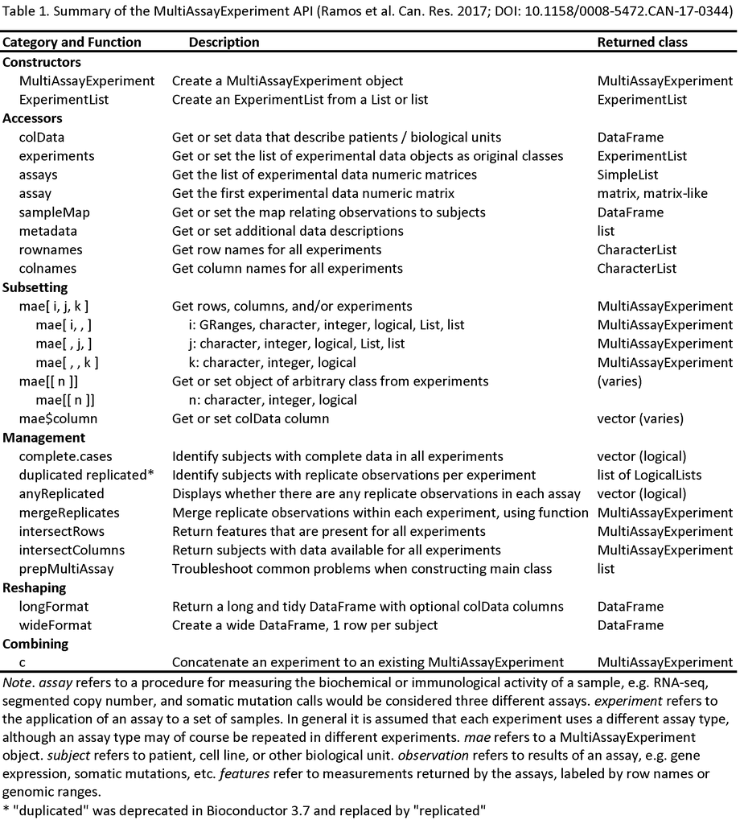

Figure 4: The MultiAssayExperiment API for construction, access, subsetting, management, and reshaping to formats for application of R/Bioconductor graphics and analysis packages

## The MultiAssayExperiment miniACC demo object

Get started by trying out `MultiAssayExperiment` using a subset of the TCGA adrenocortical carcinoma (ACC) dataset provided with the package. This dataset provides five assays on 92 patients, although all five assays were not performed for every patient:

1. **RNASeq2GeneNorm**: gene mRNA abundance by RNA-seq
2. **gistict**: GISTIC genomic copy number by gene
3. **RPPAArray**: protein abundance by Reverse Phase Protein Array
4. **Mutations**: non-silent somatic mutations by gene
5. **miRNASeqGene**: microRNA abundance by microRNA-seq.

```r
data(miniACC)
miniACC
```

```
## A MultiAssayExperiment object of 5 listed
##  experiments with user-defined names and respective classes.
##  Containing an ExperimentList class object of length 5:
##  [1] RNASeq2GeneNorm: SummarizedExperiment with 198 rows and 79 columns
##  [2] gistict: SummarizedExperiment with 198 rows and 90 columns
##  [3] RPPAArray: SummarizedExperiment with 33 rows and 46 columns
##  [4] Mutations: matrix with 97 rows and 90 columns
##  [5] miRNASeqGene: SummarizedExperiment with 471 rows and 80 columns
## Features:
##  experiments() - obtain the ExperimentList instance
##  colData() - the primary/phenotype DataFrame
##  sampleMap() - the sample availability DataFrame
##  `$`, `[`, `[[` - extract colData columns, subset, or experiment
##  *Format() - convert into a long or wide DataFrame
##  assays() - convert ExperimentList to a SimpleList of matrices
```

## colData - information biological units

This slot is a `DataFrame` describing the characteristics of biological units, for example clinical data for patients. In the prepared datasets from [The Cancer Genome Atlas][], each row is one patient and each column is a clinical, pathological, subtype, or other variable. The `$` function provides a shortcut for accessing or setting `colData` columns.

```r
colData(miniACC)[1:4, 1:4]
```

```
## DataFrame with 4 rows and 4 columns
##                 patientID years_to_birth vital_status days_to_death
##               <character>      <integer>    <integer>     <integer>
## TCGA-OR-A5J1 TCGA-OR-A5J1             58            1          1355
## TCGA-OR-A5J2 TCGA-OR-A5J2             44            1          1677
## TCGA-OR-A5J3 TCGA-OR-A5J3             23            0            NA
## TCGA-OR-A5J4 TCGA-OR-A5J4             23            1           423
```

```r
table(miniACC$race)
```

```
##
##                     asian black or african american
##                         2                         1
##                     white
##                        78
```

*Key points about the colData:*

- Each row maps to zero or more observations in each experiment in the `ExperimentList`, below.
- One row per biological unit
  - `MultiAssayExperiment` supports both missing observations and replicate observations, ie one row of `colData` can map to 0, 1, or more columns of any of the experimental data matrices.
  - therefore you could treat replicate observations as one or multiple rows of `colData`, and this will result in different behaviors of functions you will learn later like subsetting, `duplicated()`, and `wideFormat()`.
  - multiple time points, or distinct biological replicates, should probably be separate rows of the `colData`.

## ExperimentList - experiment data

A base `list` or `ExperimentList` object containing the experimental datasets for the set of samples collected. This gets converted into a class `ExperimentList` during construction.

```r
experiments(miniACC)
```

```
## ExperimentList class object of length 5:
##  [1] RNASeq2GeneNorm: SummarizedExperiment with 198 rows and 79 columns
##  [2] gistict: SummarizedExperiment with 198 rows and 90 columns
##  [3] RPPAArray: SummarizedExperiment with 33 rows and 46 columns
##  [4] Mutations: matrix with 97 rows and 90 columns
##  [5] miRNASeqGene: SummarizedExperiment with 471 rows and 80 columns
```

*Key points:*

- One matrix-like dataset per list element (although they do not even need to be matrix-like, see for example the `RaggedExperiment` package)
- One matrix column per assayed specimen. Each matrix column must correspond to exactly one row of `colData`: in other words, you must know which patient or cell line the observation came from. However, multiple columns can come from the same patient, or there can be no data for that patient.
- Matrix rows correspond to variables, e.g. genes or genomic ranges
- `ExperimentList` elements can be genomic range-based (e.g. `SummarizedExperiment::RangedSummarizedExperiment-class` or `RaggedExperiment::RaggedExperiment-class`) or ID-based data (e.g. `SummarizedExperiment::SummarizedExperiment-class`, `Biobase::eSet-class` `base::matrix-class`, `DelayedArray::DelayedArray-class`, and derived classes)
- Any data class can be included in the `ExperimentList`, as long as it supports: single-bracket subsetting (`[`), `dimnames`, and `dim`. Most data classes defined in Bioconductor meet these requirements.

## sampleMap - relationship graph

`sampleMap` is a graph representation of the relationship between biological units and experimental results. In simple cases where the column names of `ExperimentList` data matrices match the row names of `colData`, the user won’t need to specify or think about a sample map, it can be created automatically by the `MultiAssayExperiment` constructor. `sampleMap` is a simple three-column `DataFrame`:

1. `assay` column: the name of the assay, and found in the names of `ExperimentList` list names
2. `primary` column: identifiers of patients or biological units, and found in the row names of `colData`
3. `colname` column: identifiers of assay results, and found in the column names of `ExperimentList` elements Helper functions are available for creating a map from a list. See `?listToMap`

```r
sampleMap(miniACC)
```

```
## DataFrame with 385 rows and 3 columns
##               assay      primary                      colname
##            <factor>  <character>                  <character>
## 1   RNASeq2GeneNorm TCGA-OR-A5J1 TCGA-OR-A5J1-01A-11R-A29S-07
## 2   RNASeq2GeneNorm TCGA-OR-A5J2 TCGA-OR-A5J2-01A-11R-A29S-07
## 3   RNASeq2GeneNorm TCGA-OR-A5J3 TCGA-OR-A5J3-01A-11R-A29S-07
## 4   RNASeq2GeneNorm TCGA-OR-A5J5 TCGA-OR-A5J5-01A-11R-A29S-07
## 5   RNASeq2GeneNorm TCGA-OR-A5J6 TCGA-OR-A5J6-01A-31R-A29S-07
## ...             ...          ...                          ...
## 381    miRNASeqGene TCGA-PA-A5YG TCGA-PA-A5YG-01A-11R-A29W-13
## 382    miRNASeqGene TCGA-PK-A5H8 TCGA-PK-A5H8-01A-11R-A29W-13
## 383    miRNASeqGene TCGA-PK-A5H9 TCGA-PK-A5H9-01A-11R-A29W-13
## 384    miRNASeqGene TCGA-PK-A5HA TCGA-PK-A5HA-01A-11R-A29W-13
## 385    miRNASeqGene TCGA-PK-A5HB TCGA-PK-A5HB-01A-11R-A29W-13
```

*Key points:*

- relates experimental observations (`colnames`) to `colData`
- permits experiment-specific sample naming, missing, and replicate observations

back to top

## metadata

Metadata can be used to keep additional information about patients, assays performed on individuals or on the entire cohort, or features such as genes, proteins, and genomic ranges. There are many options available for storing metadata. First, `MultiAssayExperiment` has its own metadata for describing the entire experiment:

```r
metadata(miniACC)
```

```
## $title
## [1] "Comprehensive Pan-Genomic Characterization of Adrenocortical Carcinoma"
##
## $PMID
## [1] "27165744"
##
## $sourceURL
## [1] "http://s3.amazonaws.com/multiassayexperiments/accMAEO.rds"
##
## $RPPAfeatureDataURL
## [1] "http://genomeportal.stanford.edu/pan-tcga/show_target_selection_file?filename=Allprotein.txt"
##
## $colDataExtrasURL
## [1] "http://www.cell.com/cms/attachment/2062093088/2063584534/mmc3.xlsx"
```

Additionally, the `DataFrame` class used by `sampleMap` and `colData`, as well as the `ExperimentList` class, similarly support metadata. Finally, many experimental data objects that can be used in the `ExperimentList` support metadata. These provide flexible options to users and to developers of derived classes.

# MultiAssayExperiment Subsetting

## Single bracket `[`

In pseudo code below, the subsetting operations work on the rows of the following indices: 1. *i* experimental data rows 2. *j* the primary names or the column names (entered as a `list` or `List`) 3. *k* assay

```
multiassayexperiment[i = rownames, j = primary or colnames, k = assay]
```

Subsetting operations always return another `MultiAssayExperiment`. For example, the following will return any rows named “MAPK14” or “IGFBP2”, and remove any assays where no rows match:

```r
miniACC[c("MAPK14", "IGFBP2"), , ]
```

The following will keep only patients of pathological stage iv, and all their associated assays:

```r
miniACC[, miniACC$pathologic_stage == "stage iv", ]
```

```
## harmonizing input:
##   removing 311 sampleMap rows with 'colname' not in colnames of experiments
##   removing 74 colData rownames not in sampleMap 'primary'
```

And the following will keep only the RNA-seq dataset, and only patients for which this assay is available:

```r
miniACC[, , "RNASeq2GeneNorm"]
```

```
## harmonizing input:
##   removing 13 colData rownames not in sampleMap 'primary'
```

## Subsetting by genomic ranges

If any ExperimentList objects have features represented by genomic ranges (e.g. `RangedSummarizedExperiment`, `RaggedExperiment`), then a `GRanges` object in the first subsetting position will subset these objects as in `GenomicRanges::findOverlaps()`. Any non-ranged `ExperimentList` element will be subset to zero rows.

## Double bracket `[[`

```r
miniACC[[1L]]  #or equivalently, miniACC[["RNASeq2GeneNorm"]]
```

```
## class: SummarizedExperiment
## dim: 198 79
## metadata(3): experimentData annotation protocolData
## assays(1): exprs
## rownames(198): DIRAS3 MAPK14 ... SQSTM1 KCNJ13
## rowData names(0):
## colnames(79): TCGA-OR-A5J1-01A-11R-A29S-07
##   TCGA-OR-A5J2-01A-11R-A29S-07 ... TCGA-PK-A5HA-01A-11R-A29S-07
##   TCGA-PK-A5HB-01A-11R-A29S-07
## colData names(0):
```

## Complete cases

`complete.cases()` shows which patients have complete data for all assays:

```r
summary(complete.cases(miniACC))
```

```
##    Mode   FALSE    TRUE
## logical      49      43
```

The above logical vector could be used for patient subsetting. More simply, `intersectColumns()` will select complete cases and rearrange each `ExperimentList` element so its columns correspond exactly to rows of `colData` in the same order:

```r
accmatched = intersectColumns(miniACC)
```

```
## harmonizing input:
##   removing 170 sampleMap rows with 'colname' not in colnames of experiments
##   removing 49 colData rownames not in sampleMap 'primary'
```

Note, the column names of the assays in `accmatched` are not the same because of assay-specific identifiers, but they have been automatically re-arranged to correspond to the same patients. In these TCGA assays, the first three `-` delimited positions correspond to patient, ie the first patient is *TCGA-OR-A5J2*:

```r
colnames(accmatched)
```

```
## CharacterList of length 5
## [["RNASeq2GeneNorm"]] TCGA-OR-A5J2-01A-11R-A29S-07 ...
## [["gistict"]] TCGA-OR-A5J2-01A-11D-A29H-01 ... TCGA-PK-A5HA-01A-11D-A29H-01
## [["RPPAArray"]] TCGA-OR-A5J2-01A-21-A39K-20 ... TCGA-PK-A5HA-01A-21-A39K-20
## [["Mutations"]] TCGA-OR-A5J2-01A-11D-A29I-10 ...
## [["miRNASeqGene"]] TCGA-OR-A5J2-01A-11R-A29W-13 ...
```

## Row names that are common across assays

`intersectRows()` keeps only rows that are common to each assay, and aligns them in identical order. For example, to keep only genes where data are available for RNA-seq, GISTIC copy number, and somatic mutations:

```r
accmatched2 <- intersectRows(miniACC[, , c("RNASeq2GeneNorm", "gistict", "Mutations")])
rownames(accmatched2)
```

```
## CharacterList of length 3
## [["RNASeq2GeneNorm"]] DIRAS3 G6PD KDR ERBB3 AKT1S1 ... RET CDKN2A MACC1 CHGA
## [["gistict"]] DIRAS3 G6PD KDR ERBB3 AKT1S1 ... PREX1 RET CDKN2A MACC1 CHGA
## [["Mutations"]] DIRAS3 G6PD KDR ERBB3 AKT1S1 ... PREX1 RET CDKN2A MACC1 CHGA
```

back to top

# Extraction

## assay and assays

The `assay` and `assays` methods follow `SummarizedExperiment` convention. The `assay` (singular) method will extract the first element of the `ExperimentList` and will return a `matrix`.

```r
class(assay(miniACC))
```

```
## [1] "matrix"
```

The `assays` (plural) method will return a `SimpleList` of the data with each element being a `matrix`.

```r
assays(miniACC)
```

```
## List of length 5
## names(5): RNASeq2GeneNorm gistict RPPAArray Mutations miRNASeqGene
```

*Key point:*

- Whereas the `[[` returned an assay as its original class, `assay()` and `assays()` convert the assay data to matrix form.

back to top

# Summary of slots and accessors

Slot in the `MultiAssayExperiment` can be accessed or set using their accessor functions:

| Slot | Accessor |
| --- | --- |
| `ExperimentList` | `experiments()` |
| `colData` | `colData()` and `$` * |
| `sampleMap` | `sampleMap()` |
| `metadata` | `metadata()` |

__*__ The `$` operator on a `MultiAssayExperiment` returns a single column of the `colData`.

# Transformation / reshaping

The `longFormat` or `wideFormat` functions will “reshape” and combine experiments with each other and with `colData` into one `DataFrame`. These functions provide compatibility with most of the common R/Bioconductor functions for regression, machine learning, and visualization.

## `longFormat`

In *long* format a single column provides all assay results, with additional optional `colData` columns whose values are repeated as necessary. Here *assay* is the name of the ExperimentList element, *primary* is the patient identifier (rowname of colData), *rowname* is the assay rowname (in this case genes), *colname* is the assay-specific identifier (column name), *value* is the numeric measurement (gene expression, copy number, presence of a non-silent mutation, etc), and following these are the *vital_status* and *days_to_death* colData columns that have been added:

```r
longFormat(miniACC[c("TP53", "CTNNB1"), , ],
           colDataCols = c("vital_status", "days_to_death"))
```

```
## DataFrame with 518 rows and 7 columns
##               assay      primary     rowname                      colname
##         <character>  <character> <character>                  <character>
## 1   RNASeq2GeneNorm TCGA-OR-A5J1        TP53 TCGA-OR-A5J1-01A-11R-A29S-07
## 2   RNASeq2GeneNorm TCGA-OR-A5J1      CTNNB1 TCGA-OR-A5J1-01A-11R-A29S-07
## 3   RNASeq2GeneNorm TCGA-OR-A5J2        TP53 TCGA-OR-A5J2-01A-11R-A29S-07
## 4   RNASeq2GeneNorm TCGA-OR-A5J2      CTNNB1 TCGA-OR-A5J2-01A-11R-A29S-07
## 5   RNASeq2GeneNorm TCGA-OR-A5J3        TP53 TCGA-OR-A5J3-01A-11R-A29S-07
## ...             ...          ...         ...                          ...
## 514       Mutations TCGA-PK-A5HA      CTNNB1 TCGA-PK-A5HA-01A-11D-A29I-10
## 515       Mutations TCGA-PK-A5HB        TP53 TCGA-PK-A5HB-01A-11D-A29I-10
## 516       Mutations TCGA-PK-A5HB      CTNNB1 TCGA-PK-A5HB-01A-11D-A29I-10
## 517       Mutations TCGA-PK-A5HC        TP53 TCGA-PK-A5HC-01A-11D-A30A-10
## 518       Mutations TCGA-PK-A5HC      CTNNB1 TCGA-PK-A5HC-01A-11D-A30A-10
##          value vital_status days_to_death
##      <numeric>    <integer>     <integer>
## 1     563.4006            1          1355
## 2    5634.4669            1          1355
## 3     165.4811            1          1677
## 4   62658.3913            1          1677
## 5     956.3028            0            NA
## ...        ...          ...           ...
## 514          0            0            NA
## 515          0            0            NA
## 516          0            0            NA
## 517          0            0            NA
## 518          0            0            NA
```

## `wideFormat`

In *wide* format, each feature from each assay goes in a separate column, with one row per primary identifier (patient). Here, each variable becomes a new column:

```r
wideFormat(miniACC[c("TP53", "CTNNB1"), , ],
           colDataCols = c("vital_status", "days_to_death"))
```

```
## DataFrame with 92 rows and 9 columns
##          primary vital_status days_to_death RNASeq2GeneNorm_CTNNB1
##      <character>    <integer>     <integer>              <numeric>
## 1   TCGA-OR-A5J1            1          1355              5634.4669
## 2   TCGA-OR-A5J2            1          1677             62658.3913
## 3   TCGA-OR-A5J3            0            NA              6337.4256
## 4   TCGA-OR-A5J4            1           423                     NA
## 5   TCGA-OR-A5J5            1           365               5979.055
## ...          ...          ...           ...                    ...
## 88  TCGA-PK-A5H9            0            NA              5258.9863
## 89  TCGA-PK-A5HA            0            NA              8120.1654
## 90  TCGA-PK-A5HB            0            NA              5257.8148
## 91  TCGA-PK-A5HC            0            NA                     NA
## 92  TCGA-P6-A5OG            1           383              6390.0997
##     RNASeq2GeneNorm_TP53 gistict_CTNNB1 gistict_TP53 Mutations_CTNNB1
```

[output cut: 25 more lines]

# MultiAssayExperiment class construction and concatenation

## MultiAssayExperiment constructor function

The `MultiAssayExperiment` constructor function can take three arguments:

1. `experiments` - An `ExperimentList` or `list` of data
2. `colData` - A `DataFrame` describing the patients (or cell lines, or other biological units)
3. `sampleMap` - A `DataFrame` of `assay`, `primary`, and `colname` identifiers

The miniACC object can be reconstructed as follows:

```r
MultiAssayExperiment(experiments=experiments(miniACC),
                     colData=colData(miniACC),
                     sampleMap=sampleMap(miniACC),
                     metadata=metadata(miniACC))
```

```
## A MultiAssayExperiment object of 5 listed
##  experiments with user-defined names and respective classes.
##  Containing an ExperimentList class object of length 5:
##  [1] RNASeq2GeneNorm: SummarizedExperiment with 198 rows and 79 columns
##  [2] gistict: SummarizedExperiment with 198 rows and 90 columns
##  [3] RPPAArray: SummarizedExperiment with 33 rows and 46 columns
##  [4] Mutations: matrix with 97 rows and 90 columns
##  [5] miRNASeqGene: SummarizedExperiment with 471 rows and 80 columns
## Features:
##  experiments() - obtain the ExperimentList instance
##  colData() - the primary/phenotype DataFrame
##  sampleMap() - the sample availability DataFrame
##  `$`, `[`, `[[` - extract colData columns, subset, or experiment
##  *Format() - convert into a long or wide DataFrame
##  assays() - convert ExperimentList to a SimpleList of matrices
```

## `prepMultiAssay` - Constructor function helper

The `prepMultiAssay` function allows the user to diagnose typical problems when creating a `MultiAssayExperiment` object. See `?prepMultiAssay` for more details.

## `c` - concatenate to MultiAssayExperiment

The `c` function allows the user to concatenate an additional experiment to an existing `MultiAssayExperiment`. The optional `sampleMap` argument allows concatenating an assay whose column names do not match the row names of `colData`. For convenience, the *mapFrom* argument allows the user to map from a particular experiment **provided** that the **order** of the colnames is in the **same**. A `warning` will be issued to make the user aware of this assumption. For example, to concatenate a matrix of log2-transformed RNA-seq results:

```r
miniACC2 <- c(miniACC, log2rnaseq = log2(assays(miniACC)$RNASeq2GeneNorm), mapFrom=1L)
```

```
## Warning in .local(x, ...): Assuming column order in the data provided
##  matches the order in 'mapFrom' experiment(s) colnames
```

```r
experiments(miniACC2)
```

```
## ExperimentList class object of length 6:
##  [1] RNASeq2GeneNorm: SummarizedExperiment with 198 rows and 79 columns
##  [2] gistict: SummarizedExperiment with 198 rows and 90 columns
##  [3] RPPAArray: SummarizedExperiment with 33 rows and 46 columns
##  [4] Mutations: matrix with 97 rows and 90 columns
##  [5] miRNASeqGene: SummarizedExperiment with 471 rows and 80 columns
##  [6] log2rnaseq: matrix with 198 rows and 79 columns
```

back to top

## Building a MultiAssayExperiment from scratch

To start from scratch building your own MultiAssayExperiment, see the package [Coordinating Analysis of Multi-Assay Experiments vignette](https://bioconductor.org/packages/release/bioc/vignettes/MultiAssayExperiment/inst/doc/MultiAssayExperiment.html). The package [cheat sheet](https://bioconductor.org/packages/release/bioc/vignettes/MultiAssayExperiment/inst/doc/MultiAssayExperiment_cheatsheet.pdf) is also helpful.

If anything is unclear, please ask a question at https://support.bioconductor.org/ or create an issue on the [MultiAssayExperiment issue tracker](https://github.com/waldronlab/MultiAssayExperiment/issues).

# The Cancer Genome Atlas (TCGA)

Most unrestricted TCGA data are available as MultiAssayExperiment objects from the `curatedTCGAData` package. This represents a lot of harmonization!

```r
library(curatedTCGAData)
curatedTCGAData("ACC")
```

```
##                                  ACC_CNASNP
##                   "ACC_CNASNP-20160128.rda"
##                                  ACC_CNVSNP
##                   "ACC_CNVSNP-20160128.rda"
##                        ACC_GISTIC_AllByGene
##         "ACC_GISTIC_AllByGene-20160128.rda"
##                ACC_GISTIC_ThresholdedByGene
## "ACC_GISTIC_ThresholdedByGene-20160128.rda"
##                             ACC_Methylation
##              "ACC_Methylation-20160128.rda"
##                            ACC_miRNASeqGene
##             "ACC_miRNASeqGene-20160128.rda"
##                                ACC_Mutation
##                 "ACC_Mutation-20160128.rda"
##                         ACC_RNASeq2GeneNorm
##          "ACC_RNASeq2GeneNorm-20160128.rda"
##                               ACC_RPPAArray
##                "ACC_RPPAArray-20160128.rda"
```

```r
suppressMessages({
    acc <- curatedTCGAData("ACC",
        assays = c("miRNASeqGene", "RPPAArray", "Mutation", "RNASeq2GeneNorm", "CNVSNP"),
        dry.run = FALSE)
})
acc
```

```
## A MultiAssayExperiment object of 5 listed
##  experiments with user-defined names and respective classes.
##  Containing an ExperimentList class object of length 5:
##  [1] ACC_CNVSNP-20160128: RaggedExperiment with 21052 rows and 180 columns
##  [2] ACC_miRNASeqGene-20160128: SummarizedExperiment with 1046 rows and 80 columns
##  [3] ACC_Mutation-20160128: RaggedExperiment with 20166 rows and 90 columns
##  [4] ACC_RNASeq2GeneNorm-20160128: SummarizedExperiment with 20501 rows and 79 columns
##  [5] ACC_RPPAArray-20160128: SummarizedExperiment with 192 rows and 46 columns
## Features:
##  experiments() - obtain the ExperimentList instance
##  colData() - the primary/phenotype DataFrame
##  sampleMap() - the sample availability DataFrame
##  `$`, `[`, `[[` - extract colData columns, subset, or experiment
##  *Format() - convert into a long or wide DataFrame
##  assays() - convert ExperimentList to a SimpleList of matrices
```

These objects contain most unrestricted TCGA assay and clinical / pathological data, as well as material curated from the supplements of published TCGA primary papers at the end of the colData columns:

```r
dim(colData(acc))
```

```
## [1]  92 822
```

```r
tail(colnames(colData(acc)), 10)
```

```
##  [1] "MethyLevel"       "miRNA.cluster"    "SCNA.cluster"
##  [4] "protein.cluster"  "COC"              "OncoSign"
##  [7] "purity"           "ploidy"           "genome_doublings"
## [10] "ADS"
```

The `TCGAutils` package provides additional helper functions, see below.

# Utilities for TCGA

Aside from the available reshaping functions already included in the `MultiAssayExperiment` package, the *TCGAutils* package provides additional helper functions for working with TCGA data.

## “Simplification” of `curatedTCGAData` objects

A number of helper functions are available for managing datasets from `curatedTCGAData`. These include:

- Conversions of `SummarizedExperiment` to `RangedSummarizedExperiment` based on `TxDb.Hsapiens.UCSC.hg19.knownGene` for:
  - `mirToRanges`: microRNA
  - `symbolsToRanges`: gene symbols
- `qreduceTCGA`: convert `RaggedExperiment` objects to `RangedSummarizedExperiment` with one row per gene symbol, for:
  - segmented copy number datasets (“CNVSNP” and “CNASNP”)
  - somatic mutation datasets (“Mutation”), with a value of 1 for any non-silent mutation and a value of 0 for no mutation or silent mutation

The `simplifyTCGA` function combines all of the above operations to create a more managable `MultiAssayExperiment` object and using `RangedSummarizedExperiment` assays where possible.

```r
(simpa <- TCGAutils::simplifyTCGA(acc))
```

```
## A MultiAssayExperiment object of 7 listed
##  experiments with user-defined names and respective classes.
##  Containing an ExperimentList class object of length 7:
##  [1] ACC_RPPAArray-20160128: SummarizedExperiment with 192 rows and 46 columns
##  [2] ACC_Mutation-20160128_simplified: RangedSummarizedExperiment with 22945 rows and 90 columns
##  [3] ACC_CNVSNP-20160128_simplified: RangedSummarizedExperiment with 22945 rows and 180 columns
##  [4] ACC_miRNASeqGene-20160128_ranged: RangedSummarizedExperiment with 1002 rows and 80 columns
##  [5] ACC_miRNASeqGene-20160128_unranged: SummarizedExperiment with 44 rows and 80 columns
##  [6] ACC_RNASeq2GeneNorm-20160128_ranged: RangedSummarizedExperiment with 17594 rows and 79 columns
##  [7] ACC_RNASeq2GeneNorm-20160128_unranged: SummarizedExperiment with 2907 rows and 79 columns
## Features:
##  experiments() - obtain the ExperimentList instance
##  colData() - the primary/phenotype DataFrame
##  sampleMap() - the sample availability DataFrame
##  `$`, `[`, `[[` - extract colData columns, subset, or experiment
##  *Format() - convert into a long or wide DataFrame
##  assays() - convert ExperimentList to a SimpleList of matrices
```

## What types of samples are in the data?

**Solution**

The `sampleTables` function gives you an overview of samples in each assay:

```r
sampleTables(acc)
```

```
## $`ACC_CNVSNP-20160128`
##
## 01 10 11
## 90 85  5
##
## $`ACC_miRNASeqGene-20160128`
##
## 01
## 80
##
## $`ACC_Mutation-20160128`
##
## 01
## 90
##
## $`ACC_RNASeq2GeneNorm-20160128`
##
## 01
## 79
##
## $`ACC_RPPAArray-20160128`
##
## 01
## 46
```

```r
head(sampleTypes)
```

```
##   Code                                      Definition Short.Letter.Code
## 1   01                             Primary Solid Tumor                TP
## 2   02                           Recurrent Solid Tumor                TR
## 3   03 Primary Blood Derived Cancer - Peripheral Blood                TB
## 4   04    Recurrent Blood Derived Cancer - Bone Marrow              TRBM
## 5   05                        Additional - New Primary               TAP
## 6   06                                      Metastatic                TM
```

## Curated molecular subtypes

Is there subtype data available in the `MultiAssayExperiment` obtained from `curatedTCGAData`?

**Solution**

The `getSubtypeMap` function will show actual variable names found in `colData` that contain subtype information. This can only be obtained from `MultiAssayExperiment` objects provided by `curatedTCGAData`.

```r
getSubtypeMap(acc)
```

```
##          ACC_annotations     ACC_subtype
## 1             Patient_ID          SAMPLE
## 2  histological_subtypes       Histology
## 3          mrna_subtypes         C1A/C1B
## 4          mrna_subtypes         mRNA_K4
## 5                   cimp      MethyLevel
## 6      microrna_subtypes   miRNA cluster
## 7          scna_subtypes    SCNA cluster
## 8       protein_subtypes protein cluster
## 9   integrative_subtypes             COC
## 10     mutation_subtypes        OncoSign
```

```r
head(colData(acc)$Histology)
```

```
## [1] "Usual Type" "Usual Type" "Usual Type" "Usual Type" "Usual Type"
## [6] "Usual Type"
```

## Converting TCGA UUIDs to barcodes and back

`TCGAutils` provides a number of ID translation functions. These allow the user to translate from either file or case UUIDs to TCGA barcodes and back. These functions work by querying the Genomic Data Commons API via the `GenomicDataCommons` package (thanks to Sean Davis). These include:

- `UUIDtoBarcode()`
- `barcodeToUUID()`
- `UUIDtoUUID()`
- `filenameToBarcode()`

See the *TCGAutils* help pages for details.

## Other TCGA data types

Helper functions to add TCGA exon files (legacy archive), copy number and GISTIC copy number calls to MultiAssayExperiment objects are also available in *TCGAutils*.

# Plotting, correlation, and other analyses

These provide exercises and solutions using the `miniACC` dataset.

## How many `miniACC` samples have data for each combination of assays?

**Solution**

The built-in `upsetSamples` creates an “upset” Venn diagram to answer this question:

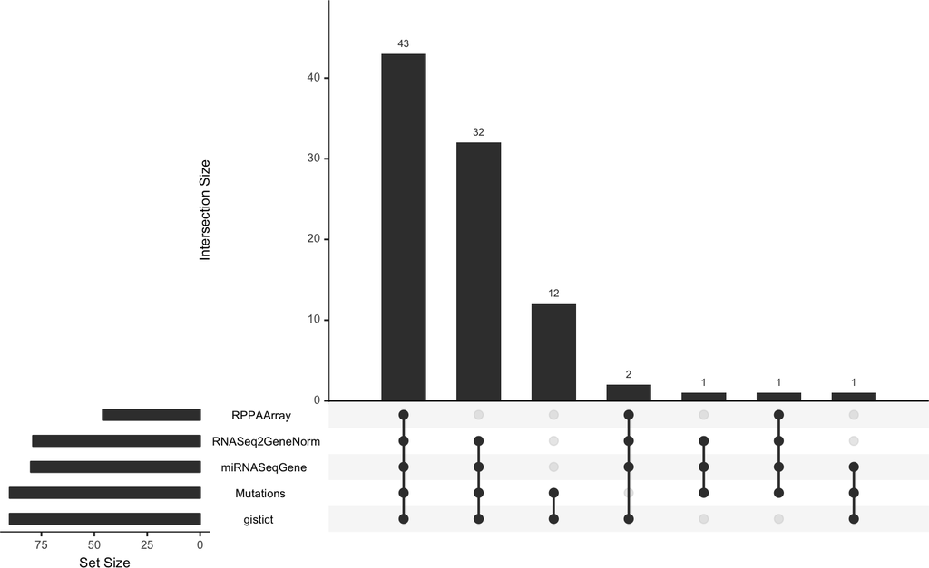

```r
upsetSamples(miniACC)
```

In this dataset only 43 samples have all 5 assays, 32 are missing reverse-phase protein (RPPAArray), 2 are missing Mutations, 1 is missing gistict, 12 have only mutations and gistict, etc.

## Kaplan-meier plot stratified by pathology_N_stage

Create a Kaplan-meier plot, using pathology_N_stage as a stratifying variable.

**Solution**

The colData provides clinical data for things like a Kaplan-Meier plot for overall survival stratified by nodal stage.

```r
Surv(miniACC$days_to_death, miniACC$vital_status)
```

```
##  [1] 1355  1677    NA+  423   365    NA+  490   579    NA+  922   551  1750
## [13]   NA+ 2105    NA+  541    NA+   NA+  490    NA+   NA+  562    NA+   NA+
## [25]   NA+   NA+   NA+   NA+  289    NA+   NA+   NA+  552    NA+   NA+   NA+
## [37]  994    NA+   NA+  498    NA+   NA+  344    NA+   NA+   NA+   NA+   NA+
## [49]   NA+   NA+   NA+   NA+   NA+  391   125    NA+ 1852    NA+   NA+   NA+
## [61]   NA+   NA+   NA+   NA+ 1204   159  1197   662   445    NA+ 2385   436
## [73] 1105    NA+ 1613    NA+   NA+ 2405    NA+   NA+   NA+   NA+   NA+  207
## [85]    0    NA+   NA+   NA+   NA+   NA+   NA+  383
```

And remove any patients missing overall survival information:

```r
miniACCsurv <- miniACC[, complete.cases(miniACC$days_to_death, miniACC$vital_status), ]
```

```
## harmonizing input:
##   removing 248 sampleMap rows with 'colname' not in colnames of experiments
##   removing 58 colData rownames not in sampleMap 'primary'
```

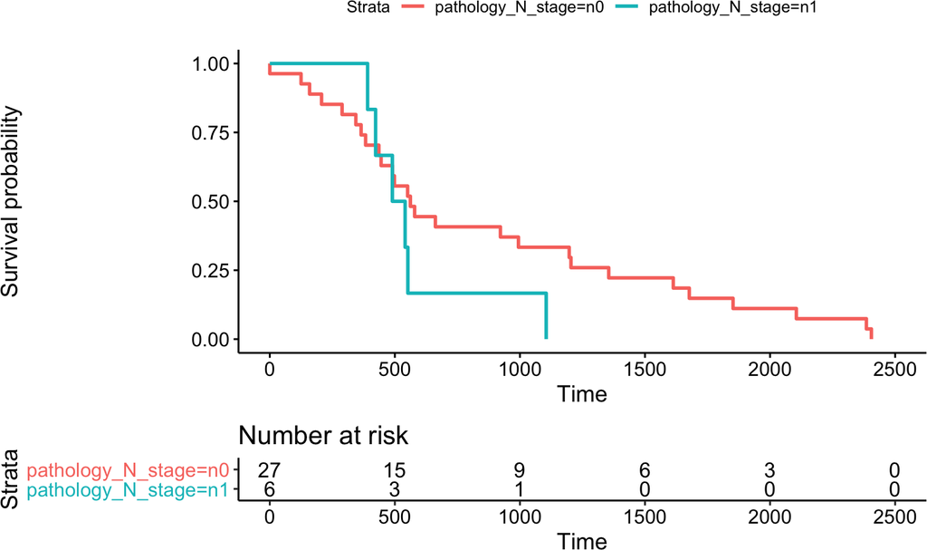

```r
fit <- survfit(Surv(days_to_death, vital_status) ~ pathology_N_stage, data = colData(miniACCsurv))
ggsurvplot(fit, data = colData(miniACCsurv), risk.table = TRUE)
```

## Multivariate Cox regression including RNA-seq, copy number, and pathology

Choose the *EZH2* gene for demonstration. This subsetting will drop assays with no row named EZH2:

```r
wideacc = wideFormat(miniACC["EZH2", , ],
    colDataCols=c("vital_status", "days_to_death", "pathology_N_stage"))
wideacc$y = Surv(wideacc$days_to_death, wideacc$vital_status)
head(wideacc)
```

```
## DataFrame with 6 rows and 7 columns
##        primary vital_status days_to_death pathology_N_stage
##    <character>    <integer>     <integer>       <character>
## 1 TCGA-OR-A5J1            1          1355                n0
## 2 TCGA-OR-A5J2            1          1677                n0
## 3 TCGA-OR-A5J3            0            NA                n0
## 4 TCGA-OR-A5J4            1           423                n1
## 5 TCGA-OR-A5J5            1           365                n0
## 6 TCGA-OR-A5J6            0            NA                n0
##   RNASeq2GeneNorm_EZH2 gistict_EZH2      y
##              <numeric>    <numeric> <Surv>
## 1              75.8886            0 1355:1
## 2             326.5332            1 1677:1
## 3              190.194            1   NA:0
## 4                   NA           -2  423:1
## 5             366.3826            1  365:1
## 6              30.7371            1   NA:0
```

Perform a multivariate Cox regression with *EZH2* copy number (gistict), log2-transformed *EZH2* expression (RNASeq2GeneNorm), and nodal status (pathology_N_stage) as predictors:

```r
coxph(Surv(days_to_death, vital_status) ~ gistict_EZH2 + log2(RNASeq2GeneNorm_EZH2) + pathology_N_stage,
      data=wideacc)
```

```
## Call:
## coxph(formula = Surv(days_to_death, vital_status) ~ gistict_EZH2 +
##     log2(RNASeq2GeneNorm_EZH2) + pathology_N_stage, data = wideacc)
##
##                               coef exp(coef) se(coef)     z       p
## gistict_EZH2               -0.0372    0.9635   0.2821 -0.13 0.89499
## log2(RNASeq2GeneNorm_EZH2)  0.9773    2.6573   0.2811  3.48 0.00051
## pathology_N_stagen1         0.3775    1.4586   0.5699  0.66 0.50774
##
## Likelihood ratio test=16.28  on 3 df, p=0.001
## n= 26, number of events= 26
##    (66 observations deleted due to missingness)
```

We see that *EZH2* expression is significantly associated with overal survival (p < 0.001), but *EZH2* copy number and nodal status are not. This analysis could easily be extended to the whole genome for discovery of prognostic features by repeated univariate regressions over columns, penalized multivariate regression, etc.

For further detail, see the main MultiAssayExperiment vignette.

back to top

## Correlation between RNA-seq and copy number

**Part 1**

For all genes where there is both recurrent copy number (gistict assay) and RNA-seq, calculate the correlation between log2(RNAseq + 1) and copy number. Create a histogram of these correlations. Compare this with the histogram of correlations between all *unmatched* gene - copy number pairs.

**Solution**

First, narrow down `miniACC` to only the assays needed:

```r
subacc <- miniACC[, , c("RNASeq2GeneNorm", "gistict")]
```

Align the rows and columns, keeping only samples with both assays available:

```r
subacc <- intersectColumns(subacc)
```

```
## harmonizing input:
##   removing 15 sampleMap rows with 'colname' not in colnames of experiments
##   removing 15 colData rownames not in sampleMap 'primary'
```

```r
subacc <- intersectRows(subacc)
```

Create a list of numeric matrices:

```r
subacc.list <- assays(subacc)
```

Log-transform the RNA-seq assay:

```r
subacc.list[[1]] <- log2(subacc.list[[1]] + 1)
```

Transpose both, so genes are in columns:

```r
subacc.list <- lapply(subacc.list, t)
```

Calculate the correlation between columns in the first matrix and columns in the second matrix:

```r
corres <- cor(subacc.list[[1]], subacc.list[[2]])
```

And finally, create the histograms:

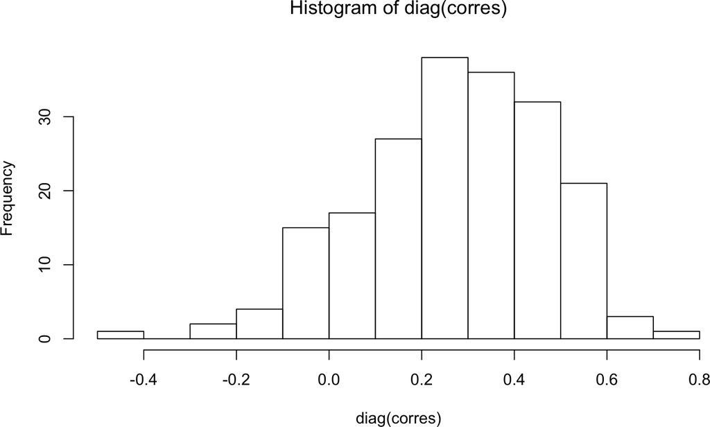

```r
hist(diag(corres))
```

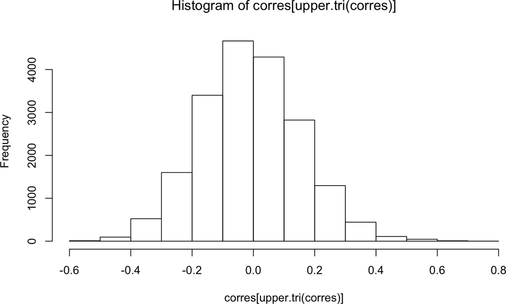

```r
hist(corres[upper.tri(corres)])
```

**Part 2**

**Solution**

First, identify the gene with highest correlation between expression and copy number:

```r
which.max(diag(corres))
```

```
## EIF4E
##    91
```

You could now make the plot by taking the EIF4E columns from each element of the list subacc.list *list* that was extracted from the subacc *MultiAssayExperiment*, but let’s do it by subsetting and extracting from the *MultiAssayExperiment*:

```r
df <- wideFormat(subacc["EIF4E", , ])
head(df)
```

```
## DataFrame with 6 rows and 3 columns
##        primary RNASeq2GeneNorm_EIF4E gistict_EIF4E
##    <character>             <numeric>     <numeric>
## 1 TCGA-OR-A5J1              460.6148             0
## 2 TCGA-OR-A5J2              371.2252             0
## 3 TCGA-OR-A5J3              516.0717             0
## 4 TCGA-OR-A5J5             1129.3571             1
## 5 TCGA-OR-A5J6              822.0782             0
## 6 TCGA-OR-A5J7              344.5648            -1
```

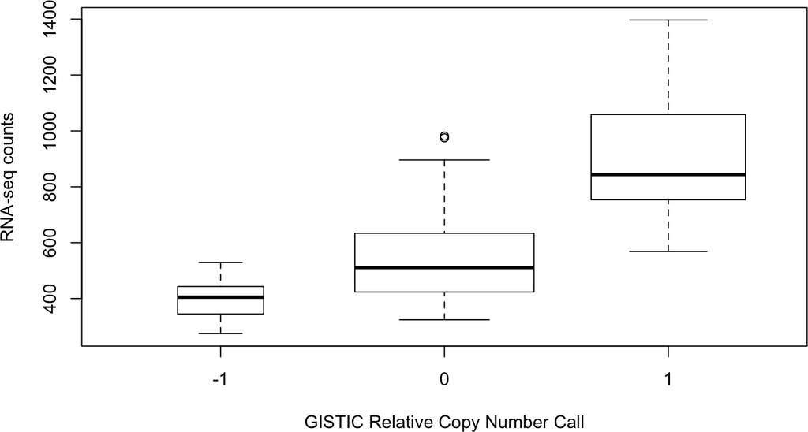

```r
boxplot(RNASeq2GeneNorm_EIF4E ~ gistict_EIF4E,
        data=df, varwidth=TRUE,
        xlab="GISTIC Relative Copy Number Call",
        ylab="RNA-seq counts")
```

back to top

## Identifying correlated principal components

Perform Principal Components Analysis of each of the five assays, using samples available on each assay, log-transforming RNA-seq data first. Using the first 10 components, calculate Pearson correlation between all scores and plot these correlations as a heatmap to identify correlated components across assays.

**Solution**

Here’s a function to simplify doing the PCAs:

```r
getLoadings <- function(x, ncomp=10, dolog=FALSE, center=TRUE, scale.=TRUE){
  if(dolog){
    x <- log2(x + 1)
  }
  pc = prcomp(x, center=center, scale.=scale.)
  return(t(pc$rotation[, 1:10]))
}
```

Although it would be possible to do the following with a loop, the different data types do require different options for PCA (e.g. mutations are a 0/1 matrix with 1 meaning there is a somatic mutation, and gistict varies between -2 for homozygous loss and 2 for a genome doubling, so neither make sense to scale and center). So it is just as well to do the following one by one, concatenating each PCA results to the MultiAssayExperiment:

```r
miniACC2 <- intersectColumns(miniACC)
```

```
## harmonizing input:
##   removing 170 sampleMap rows with 'colname' not in colnames of experiments
##   removing 49 colData rownames not in sampleMap 'primary'
```

```r
miniACC2 <- c(miniACC2, rnaseqPCA=getLoadings(assays(miniACC2)[[1]], dolog=TRUE), mapFrom=1L)
miniACC2 <- c(miniACC2, gistictPCA=getLoadings(assays(miniACC2)[[2]], center=FALSE, scale.=FALSE), mapFrom=2L)
miniACC2 <- c(miniACC2, proteinPCA=getLoadings(assays(miniACC2)[[3]]), mapFrom=3L)
miniACC2 <- c(miniACC2, mutationsPCA=getLoadings(assays(miniACC2)[[4]], center=FALSE, scale.=FALSE), mapFrom=4L)
miniACC2 <- c(miniACC2, miRNAPCA=getLoadings(assays(miniACC2)[[5]]), mapFrom=5L)
```

Now subset to keep *only* the PCA results:

```r
miniACC2 <- miniACC2[, , 6:10]
experiments(miniACC2)
```

```
## ExperimentList class object of length 5:
##  [1] rnaseqPCA: matrix with 10 rows and 43 columns
##  [2] gistictPCA: matrix with 10 rows and 43 columns
##  [3] proteinPCA: matrix with 10 rows and 43 columns
##  [4] mutationsPCA: matrix with 10 rows and 43 columns
##  [5] miRNAPCA: matrix with 10 rows and 43 columns
```

Note, it would be equally easy (and maybe better) to do PCA on all samples available for each assay, then do intersectColumns at this point instead.

Now, steps for calculating the correlations and plotting a heatmap: * Use *wideFormat* to paste these together, which has the nice property of adding assay names to the column names. * The first column always contains the sample identifier, so remove it. * Coerce to a matrix * Calculate the correlations, and take the absolute value (since signs of principal components are arbitrary) * Set the diagonals to NA (each variable has a correlation of 1 to itself).

```r
df <- wideFormat(miniACC2)[, -1]
mycors <- cor(as.matrix(df))
mycors <- abs(mycors)
diag(mycors) <- NA
```

To simplify the heatmap, show only components that have at least one correlation greater than 0.5.

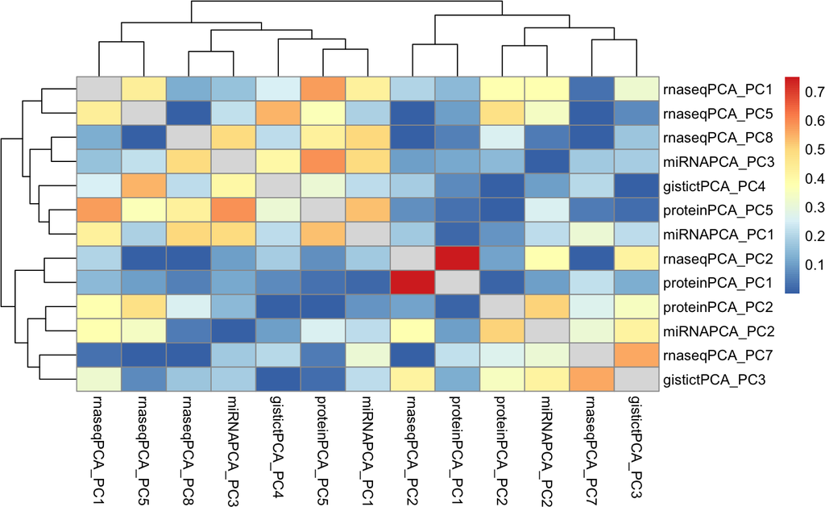

```r
has.high.cor <- apply(mycors, 2, max, na.rm=TRUE) > 0.5
mycors <- mycors[has.high.cor, has.high.cor]
pheatmap::pheatmap(mycors)
```

The highest correlation present is between PC2 of the RNA-seq assay, and PC1 of the protein assay.

back to top

## Annotating with ranges

This section doesn’t use the `TCGAutils` shortcuts, and is more generally applicable.

Convert all the `ExperimentList` elements in `miniACC` to `RangedSummarizedExperiment` objects. Then use `rowRanges` to annotate these objects with genomic ranges. For the microRNA assay, annotate instead with the genomic coordinates of predicted targets.

**Solution**

The following shortcut function takes a list of human gene symbols and uses `AnnotationFilter` and `EnsDb.Hsapiens.v86` to look up the ranges, and return these as a GRangesList which can be used to replace the rowRanges of the SummarizedExperiment objects:

```r
getrr <- function(identifiers, EnsDbFilterFunc=AnnotationFilter::SymbolFilter) {
    edb <- EnsDb.Hsapiens.v86::EnsDb.Hsapiens.v86
    afl <- AnnotationFilterList(
        EnsDbFilterFunc(identifiers),
        SeqNameFilter(c(1:21, "X", "Y")),
        TxBiotypeFilter("protein_coding"))
    gr <- genes(edb, filter=afl)
    grl <- split(gr, factor(identifiers))
    grl <- grl[match(identifiers, names(grl))]
    stopifnot(identical(names(grl), identifiers))
    return(grl)
}
```

For example:

```r
getrr(rownames(miniACC)[[1]])
```

```
## GRangesList object of length 198:
## $DIRAS3
## GRanges object with 1 range and 7 metadata columns:
##                   seqnames          ranges strand |         gene_id
##                      <Rle>       <IRanges>  <Rle> |     <character>
##   ENSG00000116288        1 7954291-7985505      + | ENSG00000116288
##                     gene_name   gene_biotype seq_coord_system      symbol
##                   <character>    <character>      <character> <character>
##   ENSG00000116288       PARK7 protein_coding       chromosome       PARK7
##                   entrezid     tx_biotype
##                     <list>    <character>
##   ENSG00000116288    11315 protein_coding
##
## $MAPK14
## GRanges object with 1 range and 7 metadata columns:
##                   seqnames          ranges strand |         gene_id
##   ENSG00000116285        1 8004404-8026308      - | ENSG00000116285
##                   gene_name   gene_biotype seq_coord_system symbol entrezid
##   ENSG00000116285    ERRFI1 protein_coding       chromosome ERRFI1    54206
##                       tx_biotype
##   ENSG00000116285 protein_coding
##
## $YAP1
## GRanges object with 1 range and 7 metadata columns:
##                   seqnames            ranges strand |         gene_id
##   ENSG00000198793        1 11106535-11262507      - | ENSG00000198793
##                   gene_name   gene_biotype seq_coord_system symbol entrezid
##   ENSG00000198793      MTOR protein_coding       chromosome   MTOR     2475
##                       tx_biotype
##   ENSG00000198793 protein_coding
##
## ...
## <195 more elements>
## -------
## seqinfo: 22 sequences from GRCh38 genome
```

```r
rseACC <- miniACC
withRSE <- c(1:3, 5)
for (i in withRSE){
  rowRanges(rseACC[[i]]) <- getrr(rownames(rseACC[[i]]))
}
```

```r
experiments(rseACC)
```

```
## ExperimentList class object of length 5:
##  [1] RNASeq2GeneNorm: RangedSummarizedExperiment with 198 rows and 79 columns
##  [2] gistict: RangedSummarizedExperiment with 198 rows and 90 columns
##  [3] RPPAArray: RangedSummarizedExperiment with 33 rows and 46 columns
##  [4] Mutations: matrix with 97 rows and 90 columns
##  [5] miRNASeqGene: RangedSummarizedExperiment with 471 rows and 80 columns
```

With ranged objects in the MultiAssayExperiment, you can then do subsetting by ranges. For example, select all genes on chromosome 1 for the four *rangedSummarizedExperiment* objects:

```r
rseACC[GRanges(seqnames="1:1-1e9"), , withRSE]
```

```
## A MultiAssayExperiment object of 3 listed
##  experiments with user-defined names and respective classes.
##  Containing an ExperimentList class object of length 3:
##  [1] RNASeq2GeneNorm: RangedSummarizedExperiment with 22 rows and 79 columns
##  [2] gistict: RangedSummarizedExperiment with 22 rows and 90 columns
##  [3] RPPAArray: RangedSummarizedExperiment with 3 rows and 46 columns
## Features:
##  experiments() - obtain the ExperimentList instance
##  colData() - the primary/phenotype DataFrame
##  sampleMap() - the sample availability DataFrame
##  `$`, `[`, `[[` - extract colData columns, subset, or experiment
##  *Format() - convert into a long or wide DataFrame
##  assays() - convert ExperimentList to a SimpleList of matrices
```

*Note about microRNA*: You can set ranges for the microRNA assay according to the genomic location of those microRNA, or the locations of their predicted targets, but we don’t do it here. Assigning genomic ranges of microRNA targets would be an easy way to subset them according to their targets.

back to top